# Practical 8

Vahe Avagyan Mathematical & Statistical Methods group – Biometris Wageningen University & Research **Linear and Generalized Linear Models** vahe.avagyan@wur.nl

### Packages

First, you need install and load the required R packages.

```r
## Set working directory to convenience
setwd(" ")

## Packages (install and invoke)
pkgs <- rownames(installed.packages())
if(!"faraway" %in% pkgs) install.packages("faraway")
if(!"MASS" %in% pkgs) install.packages("MASS")
if(!"leaps" %in% pkgs) install.packages("leaps")
if(!"MuMIn" %in% pkgs) install.packages("MuMIn")
if(!"ISLR" %in% pkgs) install.packages("ISLR")
if(!"corrplot" %in% pkgs) install.packages("corrplot")
if(!"caret" %in% pkgs) install.packages("caret")
```

The code recognizes if certain packages are missing from your package library and, if so, will install them automatically.

Now, we need to load the packages:

```r
library(faraway)
library(MASS)
library(leaps)
library(MuMIn)
library(ISLR)
library(corrplot)
library(caret)
```

## Exercise 1.

Write a regression model using 5 (out of 11) variables from the well-known `mtcars` dataset, namely:

1. `mpg`: Number of miles per US gallon.
2. `cyl`: Number of cylinders.
3. `disp`: Displacement in cubic inches.
4. `hp`: Gross horsepower.
5. `wt`: Weight in pounds.
1. Fit regression model with `mpg` as response, and `cyl`, `disp`, `hp`, `wt`as predictors. Check the regression summary. Compute correlation matrix, and indicate if there is a collinearity problem.

```r
cars_data <- mtcars[,c("mpg", "cyl", "disp", "hp", "wt")]
head(cars_data)
```

```
##                    mpg cyl disp  hp    wt
## Mazda RX4         21.0   6  160 110 2.620
## Mazda RX4 Wag     21.0   6  160 110 2.875
## Datsun 710        22.8   4  108  93 2.320
## Hornet 4 Drive    21.4   6  258 110 3.215
## Hornet Sportabout 18.7   8  360 175 3.440
## Valiant           18.1   6  225 105 3.460
```

```r
#Create a linear regression model
cars_model <- lm(mpg~., data = cars_data)
summary(cars_model)
```

```
##
## Call:
## lm(formula = mpg ~ ., data = cars_data)
##
## Residuals:
##     Min      1Q  Median      3Q     Max
## -4.0562 -1.4636 -0.4281  1.2854  5.8269
##
## Coefficients:
##             Estimate Std. Error t value Pr(>|t|)
## (Intercept) 40.82854    2.75747  14.807 1.76e-14 ***
## cyl         -1.29332    0.65588  -1.972 0.058947 .
## disp         0.01160    0.01173   0.989 0.331386
## hp          -0.02054    0.01215  -1.691 0.102379
## wt          -3.85390    1.01547  -3.795 0.000759 ***
## ---
## Signif. codes:  0 '***' 0.001 '**' 0.01 '*' 0.05 '.' 0.1 ' ' 1
##
## Residual standard error: 2.513 on 27 degrees of freedom
## Multiple R-squared:  0.8486, Adjusted R-squared:  0.8262
## F-statistic: 37.84 on 4 and 27 DF,  p-value: 1.061e-10
```

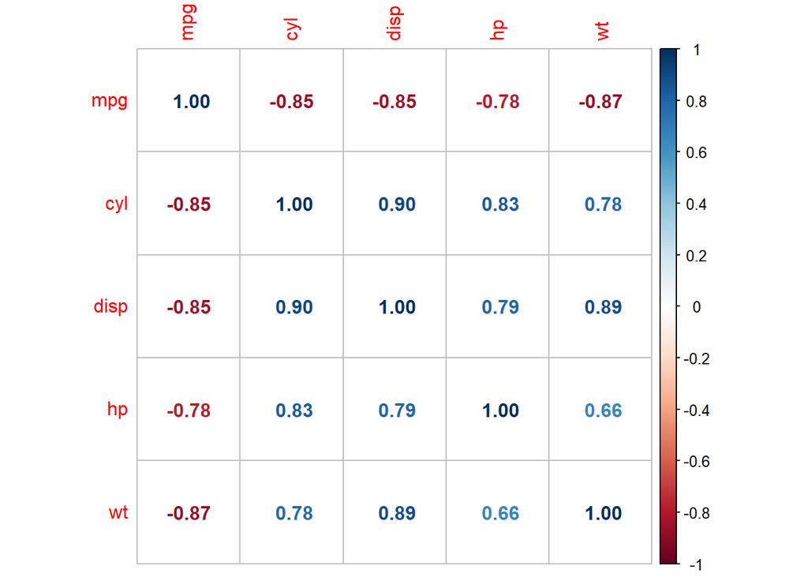

```r
corrplot(cor(cars_data), method = "number")
```

The matrix above shows the correlation matrix of the variables that are included in our regression model. The high correlation between `disp` and `cyl` (0.90) might indicate multicollinearity.

2. For the same model, compute the VIFs. Is there evidence of multicollinearity. Calculate the VIF manually, for one of the variables.

```r
vif(cars_model)
```

```
##       cyl      disp        hp        wt
##  6.737707 10.373286  3.405983  4.848016
```

We can see that the variable `disp` has a VIF above 10. Therefore, multicollinearity is highly likely. It is suggesting that the standard error is inflated by factor $10.37^{0.5}$.

We can calculate the VIF for `disp` as $1/(1-R_{disp}^2)$, where $R_{disp}^2$ is the $R^2$ of the regression model with `disp` as a response variable agains the remaining predictors.

```r
cars_model_disp <- lm(disp ~ cyl + hp + wt, data = cars_data)
R2_disp <- summary(cars_model_disp)$r.squared
(VIF_disp <- 1/(1-R2_disp))
```

```
## [1] 10.37329
```

3. Does the removal of the insignificant predictors from the model reduce the collinearity?

```r
 cars_model2 <- update(cars_model, . ~.-disp)
 vif(cars_model2)
```

```
##      cyl       hp       wt
## 4.757456 3.258481 2.580486
```

```r
 summary(cars_model2)
```

```
##
## Call:
## lm(formula = mpg ~ cyl + hp + wt, data = cars_data)
##
## Residuals:
##     Min      1Q  Median      3Q     Max
## -3.9290 -1.5598 -0.5311  1.1850  5.8986
##
## Coefficients:
##             Estimate Std. Error t value Pr(>|t|)
## (Intercept) 38.75179    1.78686  21.687  < 2e-16 ***
## cyl         -0.94162    0.55092  -1.709 0.098480 .
## hp          -0.01804    0.01188  -1.519 0.140015
## wt          -3.16697    0.74058  -4.276 0.000199 ***
## ---
## Signif. codes:  0 '***' 0.001 '**' 0.01 '*' 0.05 '.' 0.1 ' ' 1
##
## Residual standard error: 2.512 on 28 degrees of freedom
## Multiple R-squared:  0.8431, Adjusted R-squared:  0.8263
## F-statistic: 50.17 on 3 and 28 DF,  p-value: 2.184e-11
```

```r
 anova(cars_model, cars_model2)
```

```
## Analysis of Variance Table
##
## Model 1: mpg ~ cyl + disp + hp + wt
## Model 2: mpg ~ cyl + hp + wt
##   Res.Df    RSS Df Sum of Sq      F Pr(>F)
## 1     27 170.44
## 2     28 176.62 -1   -6.1762 0.9784 0.3314
```

By removing `disp` variable, the multicollinearity issue is solved. Note that it was insignificant. The F-test also shows that the reduced model is as good as the complete model.